# A8_20019803

```r
sum(int_sig) #significant ~5% of the time
```

```
## [1] 56
```

8. Code for an outer loop running through at least 10 values of the parameter (total_n or sres) that you are examining.

```r
nreps  <- 1000
sres_rs <- 1.2
k = 1

#we're gonna intialize three data frames for our predictors rather than three vectors to enable storage of all the data from our 10 runs in the same framework. This will enable easier analysis down the road.
p_hch <- data.frame(1,2,3,4,5,6,7,8,9,10)
p_ddt <- data.frame(1,2,3,4,5,6,7,8,9,10)
p_int <- data.frame(1,2,3,4,5,6,7,8,9,10)

#name the columns of each data frame based on the sres value they'll contain
colnames(p_hch) <- c("hch_sres_1.2","hch_sres_1.1","hch_sres_1.0","hch_sres_0.9","hch_sres_0.8","hch_sres_0.7","hch_sres_0.6","hch_sres_0.5","hch_sres_0.4","hch_sres_0.3")
colnames(p_ddt) <- c("ddt_sres_1.2","ddt_sres_1.1","ddt_sres_1.0","ddt_sres_0.9","ddt_sres_0.8","ddt_sres_0.7","ddt_sres_0.6","ddt_sres_0.5","ddt_sres_0.4","ddt_sres_0.3")
colnames(p_int) <- c("int_sres_1.2","int_sres_1.1","int_sres_1.0","int_sres_0.9","int_sres_0.8","int_sres_0.7","int_sres_0.6","int_sres_0.5","int_sres_0.4","int_sres_0.3")

while (k <= 10){
  #this outer loop runs 10 times, as k starts at 1 and increases by 1 every cycle.
  #each cycle decreases the sres value by 0.1.
  for (i in 1:nreps){
    #The inner loop has been slightly modified to reflect the fact that we are using dataframes rather than vectors, thus requring two dimensions
    datrep <- pre
    datrep$rep <- rep(NA,length=length(datrep$hch))
    for(j in 1:length(datrep$rep)){
      #the innermost loop used from the last question
      datrep$rep[j] <- floor(rnorm(1,mean = gmean_rs +
                            hch.effect[datrep$hch[j]] +
                            ddt.effect[datrep$ddt[j]] +
                            dxh.effect[datrep$hch[j], datrep$ddt[j]],
                            sd = sres_rs) )
      if (datrep$rep[j]<0){
        datrep$rep[j]=0
      }
      else{
      datrep$rep[j]=datrep$rep[j]
      }# can't have less than 0 babies!
    }
    res <- Anova(lm(rep~ddt*hch,dat=datrep))
    p_ddt[i,k] <- as.numeric(res$`Pr(>F)`[1])
    p_hch[i,k] <- as.numeric(res$`Pr(>F)`[2])
    p_int[i,k] <- as.numeric(res$`Pr(>F)`[3])
  }
sres_rs = sres_rs - 0.1
k = k+1
}
```

9. For each batch of simulated data, you will run the analysis of your experimental factors using lm() and collect the P values from applying the Anova() function to the resulting lm() object.
10. With these P values, you should calculate, for each value of total_n or sres, the statistical power (frequency with which you reject the null hypothesis when it is false) for each term in the model.

```r
ddt_sig <- ifelse(p_ddt <= 0.05,1,0) #get significant p values
hch_sig <- ifelse(p_hch <= 0.05,1,0)
int_sig <- ifelse(p_int <= 0.05,1,0)

(results.df <- data.frame(sres = sub(".*_","",names(colSums(ddt_sig))),DDT = (colSums(ddt_sig)/10), HCH = (colSums(hch_sig)/10), DDT_HCH_interaction = (colSums(int_sig)/10 )) )#add up all the 1's in each column and devide by 10 to get the percent of significant p values for each column. Order by predictor and sres
```

```
##              sres  DDT  HCH DDT_HCH_interaction
## ddt_sres_1.2  1.2 24.8 17.6                 4.4
## ddt_sres_1.1  1.1 28.6 20.5                 4.0
## ddt_sres_1.0  1.0 34.2 25.2                 4.7
## ddt_sres_0.9  0.9 40.6 28.5                 5.1
## ddt_sres_0.8  0.8 51.9 32.2                 4.9
## ddt_sres_0.7  0.7 60.2 38.4                 5.0
## ddt_sres_0.6  0.6 74.5 49.2                 3.8
## ddt_sres_0.5  0.5 84.2 64.9                 4.7
## ddt_sres_0.4  0.4 94.5 77.2                 6.6
## ddt_sres_0.3  0.3 98.0 86.0                10.1
```

```r
results.df <- pivot_longer(results.df, -sres, names_to = "Predictor", values_to = "significant" )
#data converted from wide to long format for easier analyis
```

11. Make a publication-quality figure (with appropriate caption) illustrating your results. You should plot the lines for all three effects (sex, pH, interaction) on the same graph and annotate the graph so we know which line is which.

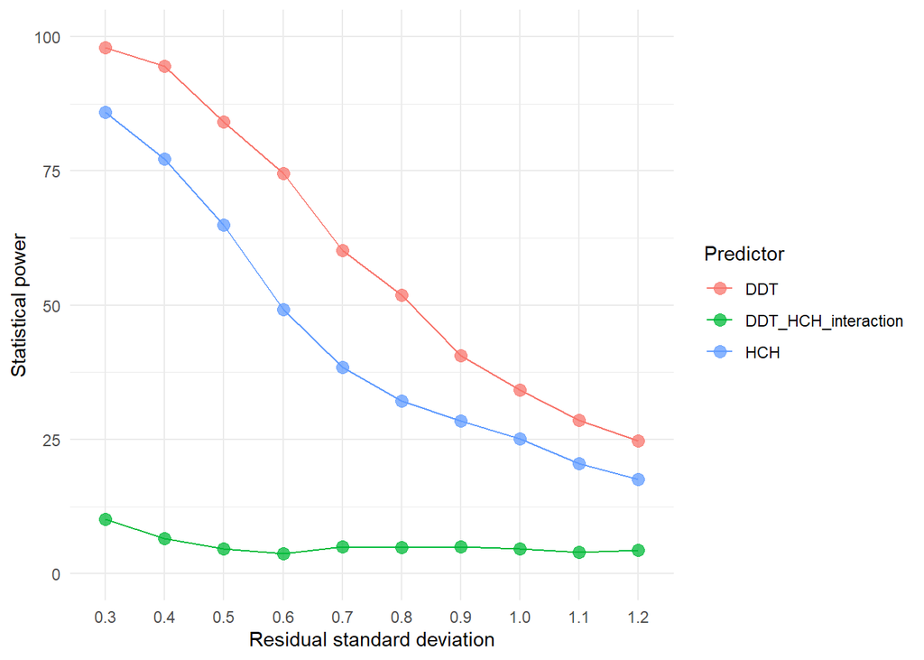

```r
  pd <- position_dodge(width = 0.2)

ggplot(data = results.df, aes(x = sres, y =significant, group = Predictor, colour = Predictor)) +
  geom_point(size = 3, alpha = 0.75) +
  geom_line() +
  labs(x = "Residual standard deviation", y = "Statistical power") +
  ylim(0,100) +
  theme_minimal()
```

Figure 1. Statistical power of chemical pollutants as predictors of mating success plotted against residual standard deviation in mating success. DDT appears in red, HCH in blue, and the DDTxHCH interaction appears in green.

12. In a text section in your R notebook, interpret your results and describe how varying sample size (total_n) or trait variation (sres) affects frequency of statistical errors.